# MoME and SuperLearner

Valerio Ferdinando Calà

21/7/2023

## MoME in a nutshell

The model **MoME** (*modello monitoraggio entrate*) was developed by the Ministry of Economy and Finance (MEF) to forecast (with 1 month horizon) the four (4) major Government tax revenues, which toghether comprimises more than 70% of the total tax revenue:  
1. VAT on domestic markets  
2. VAT on import  
3. Excises on energetic products  
4. Labour income tax (IRPEF)

For each tax there is a regression equation: we present all the estimated equations, using the convention to put a “hat” in all the estimated parameters (on the right hand side of the equation) and fitted values (on the left hand side).

Moreover, with the only exception of the excises taxes, we have auxiliary equations which help to estimate the following explanatory variables: turnovers, import and labour income $\left(\{FAT_t\}, \{IMP_t\}, \{RED_t\}\right)$.

As stated cleary by the authors, the goal is to provide effective predictions 1 month ahead while retaining the simplest possible models. There is no interest in coefficients’ interpretations, as long as the output predictions are reliable.

It is worth noting that the model was trained before Covid pandemic crisis, hence we should expect on average overpredictions (i.e. negative residuals) during those time periods.

**1. VAT on domestic markets**

$\widehat{(IVAI_t - IVAI_{t-12})} = \widehat{a}_0 + \widehat{b}_1 (FAT_{t-1}-FAT_{t-13}) + \widehat{a}_1 (IVAI_{t-1}-IVAI_{t-13}) + \widehat{a}_{12}IVAI_{t-12}$

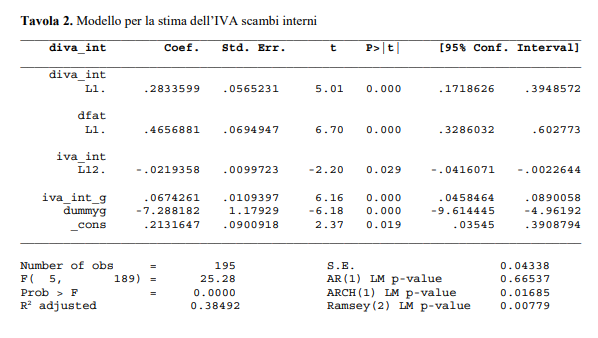

**2. Auxiliary equation for FAT**

$\widehat{FAT}_t = \widehat{c}_0 + \widehat{c}_{12}FAT_{t-12} + \widehat{d}_1 (RED_{t-1} - RED_{t-13})$

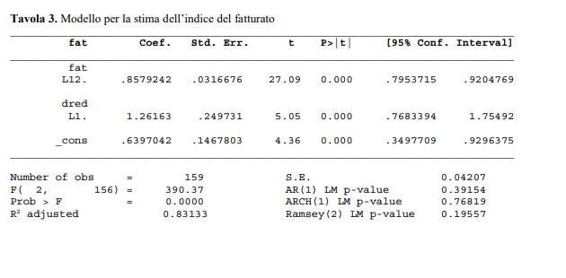

**3. VAT on import**

$\widehat{IVAE}_t = \widehat{a}_0 + \widehat{a}_1 IVAE_{t-1} + \widehat{a}_{12} IVAE_{t-12} + \widehat{b}_0 IMP_t + \widehat{b}_1 IMP_{t-1} + \widehat{b}_{12} IMP_{t-12}$

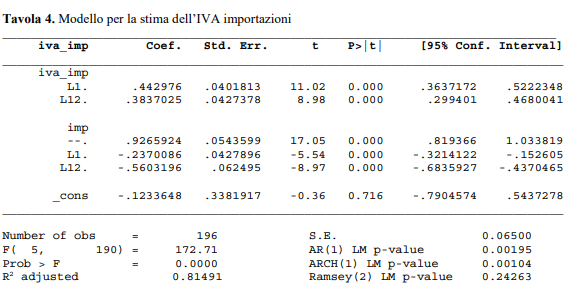

**4. Auxiliary equation for IMP**

$\widehat{IMP}_t = \widehat{c}_0 + \widehat{c}_1 IMP_{t-1} + \widehat{c}_2 IMP_{t-2} + \widehat{c}_{12}IMP_{t-12} + \widehat{c}_{13}IMP_{t-13} + \widehat{c}_{14}IMP_{t-14} + \widehat{d}_1FAT_t + \widehat{d}_{12}FAT_{t-12}$

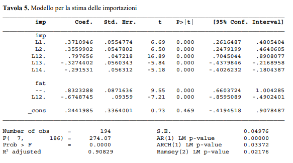

**5. Excises on energy products**

$\widehat{ACC}_t = \widehat{a}_0 + \widehat{a}_{12} ACC_{t-12}$

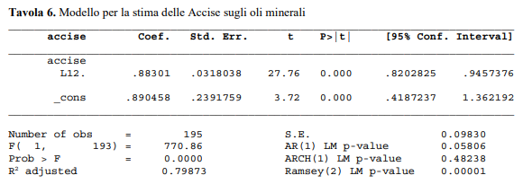

**6. Labour income tax (IRPEF)**

$\widehat{IRPEF}_t = \widehat{a}_0 + \widehat{a}_1 IRPEF_{t-1} + \widehat{a}_{12} IRPEF_{t-12} + \widehat{a}_{13} IRPEF_{t-13} + \widehat{b}_1 (RED_{t-1}-RED_{t-13})$

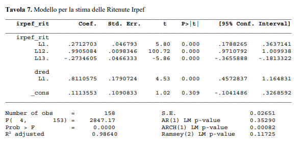

**7. Auxiliary equation for RED**

$\widehat{RED}_{t} = \widehat{c}_0 + \widehat{c}_1 RED_{t-1} + \widehat{c}_{12}RED_{t-12} + \widehat{d}_1 D_t + \widehat{d}_2 (FAT_{t-1}-FAT_{t-13})$

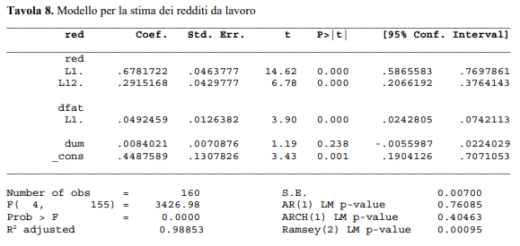

## 1 month ahead predictions

In the following code-chunks, I will replicate the **MoME** as reported in the MEF working paper (LINK: https://www.finanze.it/export/sites/finanze/.galleries/Documenti/Varie/dfwp5_2020.pdf), by adopting the same parameter estimate for each equation. The logic throughout the code is the following: firstly, we mutate the original dataset to include all the transformed variable that we need (lagged or differenced as stated in the equations above); then, we show both visually and numerically, for each targeted series, which the performance of the model in-sample (training data used by the authors: from January 2002 to December 2018) and out-of-sample (from January 2019 to January 2023).

```r
# required packages
require(dplyr)
require(readxl)
require(forecast)
require(tidymodels)
require(ggplot2)
require(nlme)
require(gridExtra)
require(stringr)

# read and pre-process data

df <- read_excel("dati_MoME.xlsx")

variable_names <- c('diva_int', 'fat', 'iva_imp', 'imp', 'accise', 'irpef_rit', 'red')

df$dum <- as.logical(df$dum)

df <- df[1:252,]

df_log <- df %>%
          select(where(is.numeric)) %>%
          as.matrix() %>%
          log() %>%
          as.data.frame()

df_log <- df_log %>%
  mutate(
    L1_iva_imp = lag(iva_imp),
    L12_iva_imp = lag(iva_imp, n=12),
    L1_imp = lag(imp),
    L2_imp = lag(imp, n=2),
    L12_imp = lag(imp, n=12),
    L13_imp = lag(imp, n=13),
    L14_imp = lag(imp, n=14),
    L12_iva_int = lag(iva_int, n=12),
    L12_accise = lag(accise, n=12),
    L12_fat = lag(fat, n=12),
    L1_irpef_rit = lag(irpef_rit),
    L12_irpef_rit = lag(irpef_rit, n=12),
    L13_irpef_rit = lag(irpef_rit, n=13),
    L1_red = lag(red),
    L12_red = lag(red, n=12)
  ) %>%
  mutate(
    diva_int = iva_int - L12_iva_int,
    dfat = fat - L12_fat,
    dred = red - L1_red
  ) %>%
  mutate(
    L1_diva_int = lag(diva_int),
    L1_dfat = lag(dfat),
    L1_dred = lag(dred)
  )


df <- df %>% select(data, dum) %>% bind_cols(df_log)

rm(df_log)

# eq1: diva_int ~ L1.diva_int + L1.dfat + L12.iva_int
coeff_1 = c(.2833599, .4656881, -.0219358, .2131647)
df$fitted_diva_int = df %>% select(L1_diva_int, L1_dfat, L12_iva_int) %>%
  mutate(cons = rep(1, nrow(df))) %>% as.matrix() %*% coeff_1 %>% as.numeric()

# eq2: fat ~ L12.fat + L1.dred
coeff_2 = c(.8579242, 1.26163, .6397042)
df$fitted_fat = df %>% select(L12_fat, L1_dred) %>%
  mutate(cons = rep(1, nrow(df))) %>% as.matrix() %*% coeff_2 %>% as.numeric()

# switch equations 3 and 4 because we need only lagged or fitted values on the RHS

# eq4: imp ~ L1.imp + L2.imp + L12.imp + L13.imp + L14.imp + fat + L12.fat
coeff_4 = c(.3710946, .3559902, .797656, -.3274402,
            -.291531, .8323288, -.6748745, .2441985)
df$fitted_imp = df %>% select(L1_imp, L2_imp, L12_imp, L13_imp, L14_imp, fitted_fat, L12_fat) %>%
  mutate(cons = rep(1, nrow(df))) %>% as.matrix() %*% coeff_4 %>% as.numeric()

# eq3: iva_imp ~ L1.iva_imp + L12.iva_imp + imp + L1.imp + L12.imp
coeff_3 = c(.442976, .3837025, .9265924, -.2370086, -.5603196, -.1233648)
df$fitted_iva_imp = df %>% select(L1_iva_imp, L12_iva_imp, fitted_imp, L1_imp, L12_imp) %>%
  mutate(cons = rep(1, nrow(df))) %>% as.matrix() %*% coeff_3 %>% as.numeric()

# eq5: acc ~ L12.acc
coeff_5 = c(.88301, .890458)
df$fitted_accise = df %>% select(L12_accise) %>%
    mutate(cons = rep(1, nrow(df))) %>% as.matrix() %*% coeff_5 %>% as.numeric()

# eq6: irpef_rit ~ L1.irpef_rit + L12.irpef_rit + L13.irpef_rit + L1.dred
coeff_6 = c(.2712703, .9905084, -.2734605, .8110575, .1113553)
df$fitted_irpef_rit = df %>% select(L1_irpef_rit, L12_irpef_rit, L13_irpef_rit, L1_dred) %>%
    mutate(cons = rep(1, nrow(df))) %>% as.matrix() %*% coeff_6 %>% as.numeric()

# eq7: red ~ L1.red + L12.red + L1.dfat + dum
coeff_7 = c(.6781722, .2915168, .0492459, .0084021, .4487589)
df$fitted_red = df %>% select(L1_red, L12_red, L1_dfat, dum) %>%
    mutate(cons = rep(1, nrow(df))) %>% as.matrix() %*% coeff_7 %>% as.numeric()


# generate residuals
df = df %>% mutate(
  e_diva_int = diva_int-fitted_diva_int,
  e_fat = fat - fitted_fat,
  e_iva_imp = iva_imp - fitted_iva_imp,
  e_imp = imp - fitted_imp,
  e_accise = accise - fitted_accise,
  e_irpef_rit = irpef_rit - fitted_irpef_rit,
  e_red = red - fitted_red
)
```

Here we can visualize the model performance over both the training and testing period. For each variable we can see in the first row the scatterplot between predicted and true values (which should be equally distributed near the identity function) and the actual and predicted (**in red**) time series (which should be each other as close as possible); in the second row we can residuals diagnosis (estimated density function and scatter plot of residual against predicted values, which should be mean 0 - reference in dot line - and orthogonal each other).

Overall, in-sample results look promising: with the only exception for the ‘Accise’, all the remaining fitted time series mimic very well the actual ones prior 2018.

Moreover, we can see that also for time periods after December 2018 (last training data point) we still would get amazing results **IF** each time series is observed monthly and the forecast horizon is limited to 1 month ahead, as we have done in this projections (since we are just applying the already estimated coefficients to each equations, plugging-in for each period the true relevant lagged values).

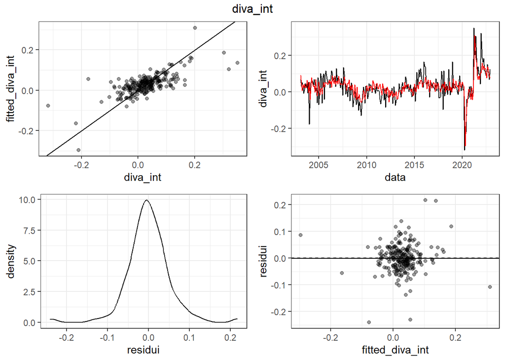

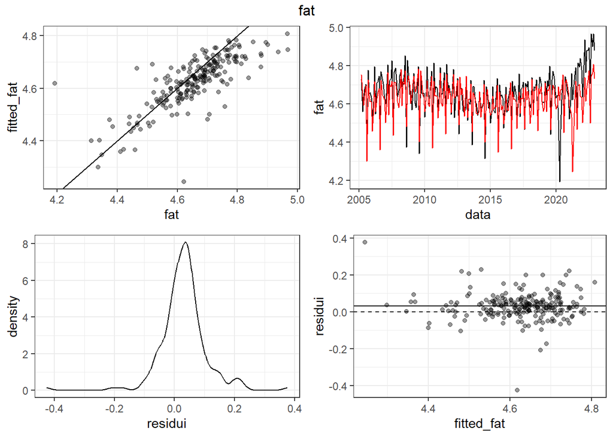

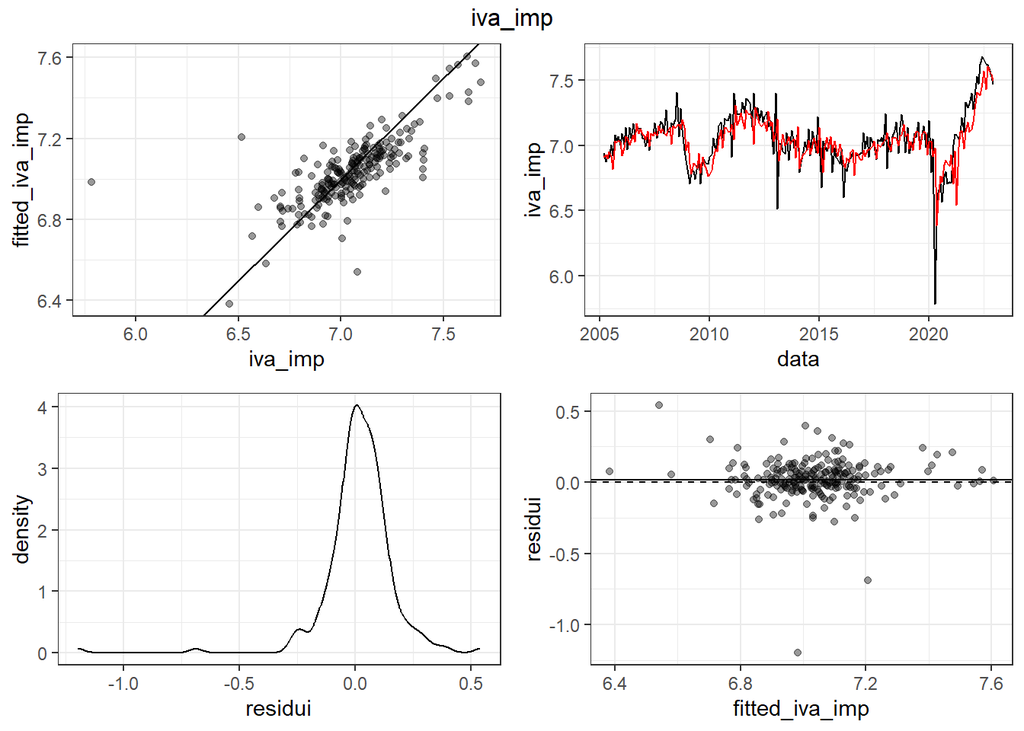

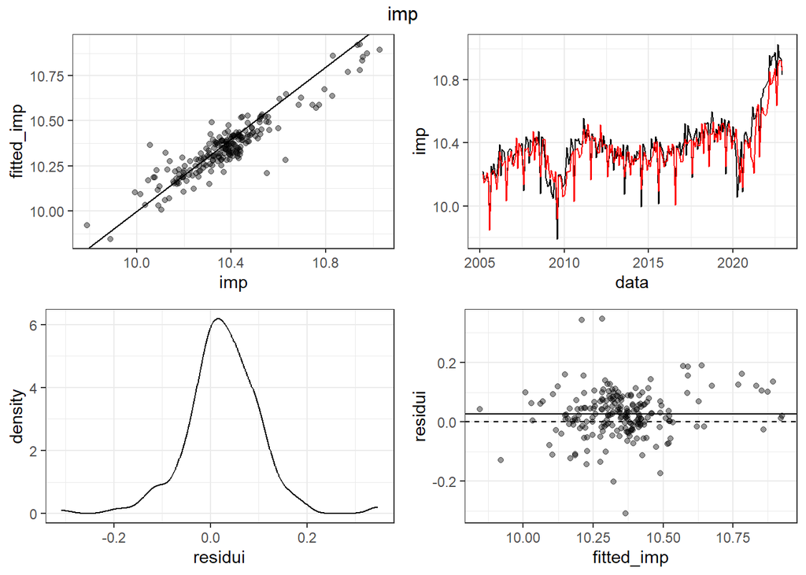

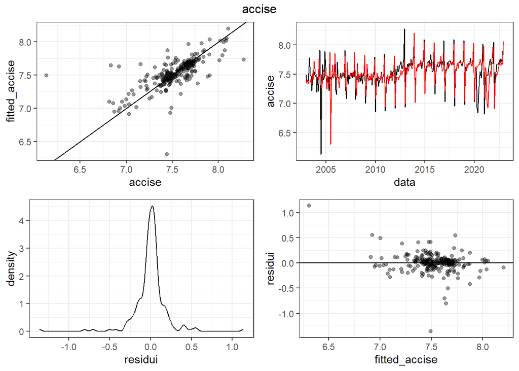

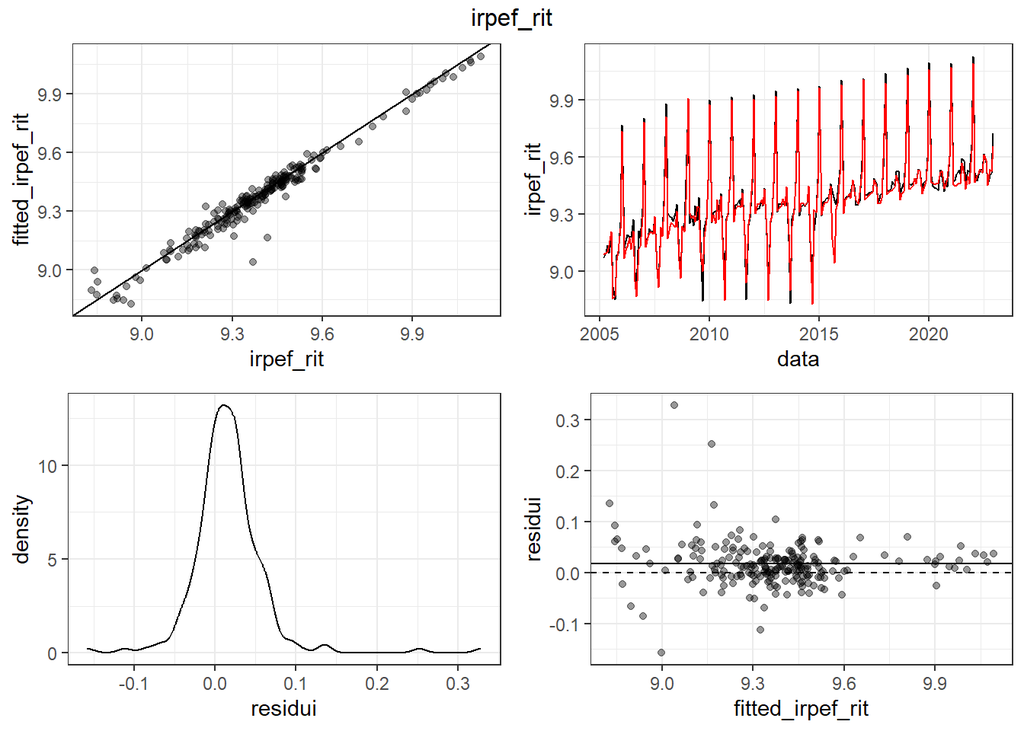

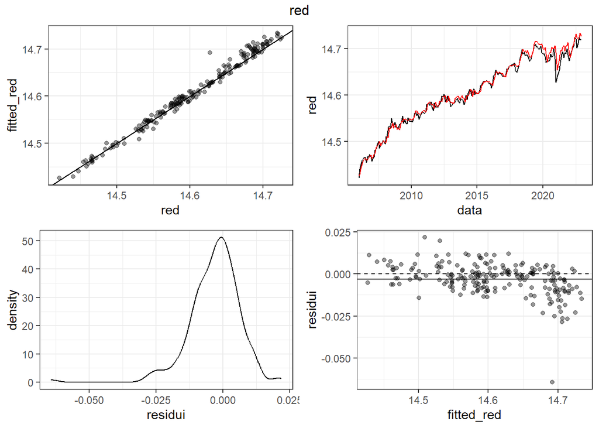

```r
# mean residal values
mean_residuals <- df %>%
                  na.omit() %>%
                  select(starts_with('e_')) %>%
                  lapply(mean) %>%
                  as.numeric()

names(mean_residuals) <- variable_names

## plot in sample performances
my_plot_fun <- function(df=df, nome_variabile) {

  dati = df %>% select(data, contains(nome_variabile)) %>% na.omit()

  g1 = ggplot(dati, aes_string(x=nome_variabile, y=paste0('fitted_',nome_variabile))) +
          geom_point(alpha = .4) +
          geom_abline(slope=1, intercept=0) +
          theme_bw()

  g2 = ggplot(dati, aes_string(x = paste0('e_',nome_variabile))) +
          geom_density() +
          xlab('residui') +
          theme_bw()

  g3 = ggplot(dati, aes_string(x ='data', y = nome_variabile)) +
    geom_line() +
    geom_line(aes_string(y = paste0('fitted_',nome_variabile)), color = 'red') +
    theme_bw()

  g4 = ggplot(dati, aes_string(
        x=paste0('fitted_',nome_variabile),  y=paste0('e_',nome_variabile))
        ) +
        geom_point(alpha=0.4) + ylab('residui') +
        geom_hline(yintercept = 0, lty=2) +
        geom_hline(yintercept = as.numeric(mean_residuals[nome_variabile]), lty=1) +
        theme_bw()

  grid.arrange(g1, g3, g2, g4, nrow=2, top = nome_variabile)
}

for (v in c('diva_int', 'fat', 'iva_imp', 'imp', 'accise', 'irpef_rit', 'red')) {
  my_plot_fun(df=df, nome_variabile = v)
  }
```

Here we can zoom-in the predictions reported above but in the test set (all time points after December 2018). This is still 1 month ahead predictions. Both residual distributions and metric performances are slightly worse off, but overall the results are still quite good.

It is worth it to stress the fact that, to truly test model performance over a larger time horizon, we should do a different exercise and plug-in estimated lagged values in all the previous equations. In this case we are supposing that for all the subsequent point prediction the information available compromises the true actual values, which are observed with a monthly frequency.

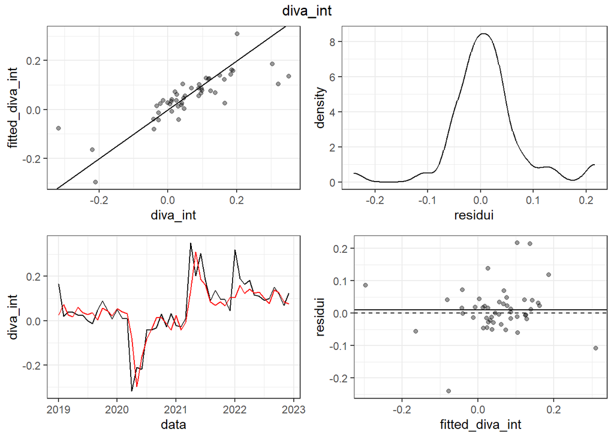

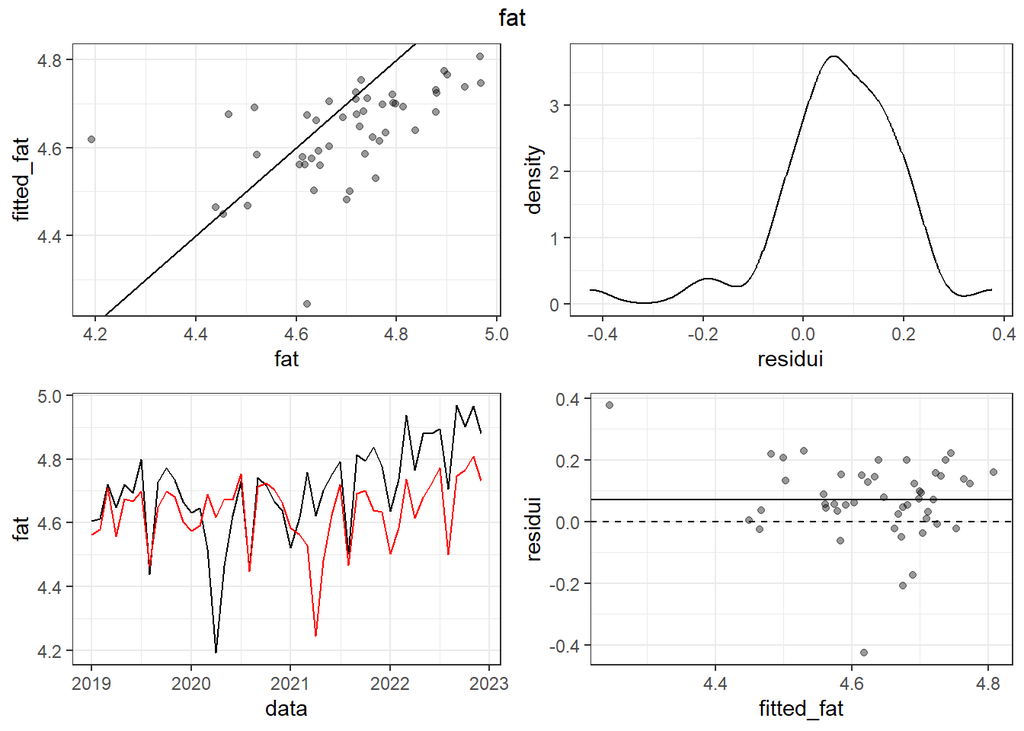

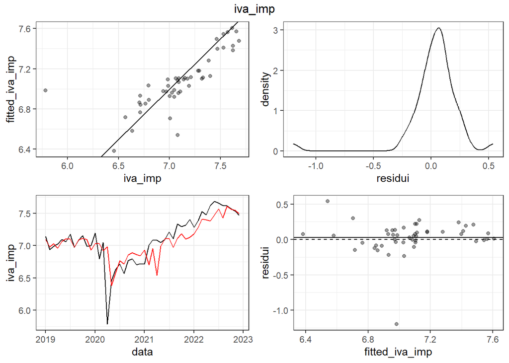

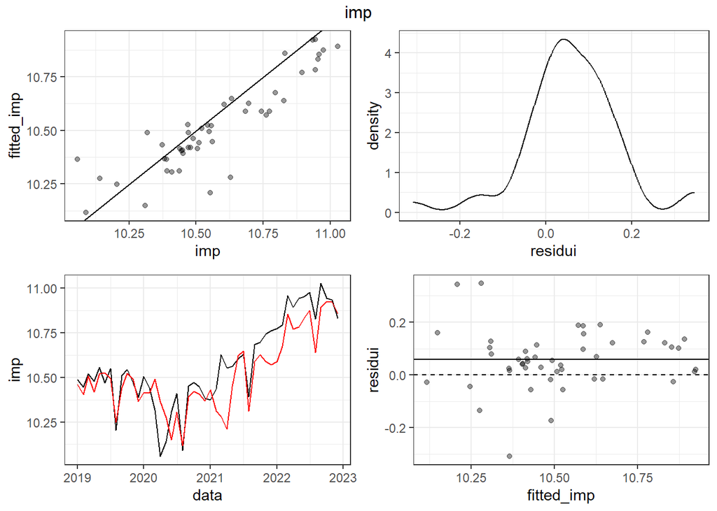

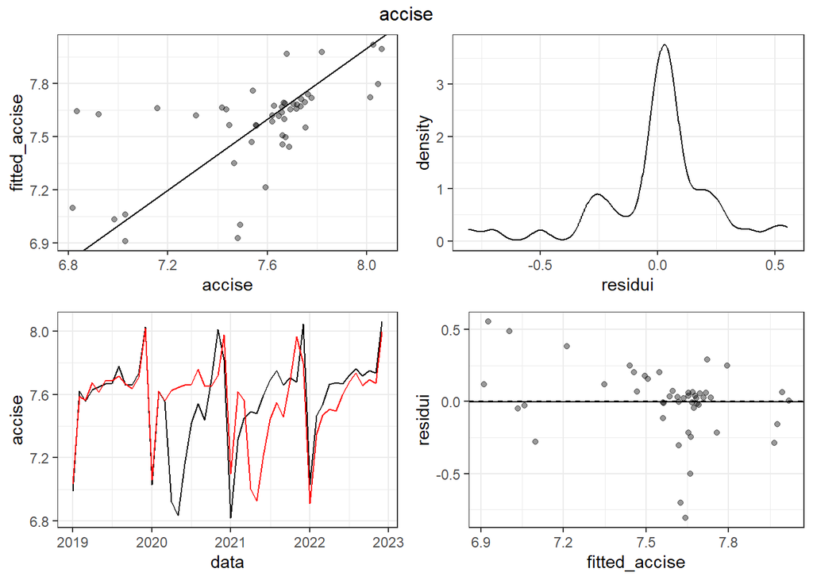

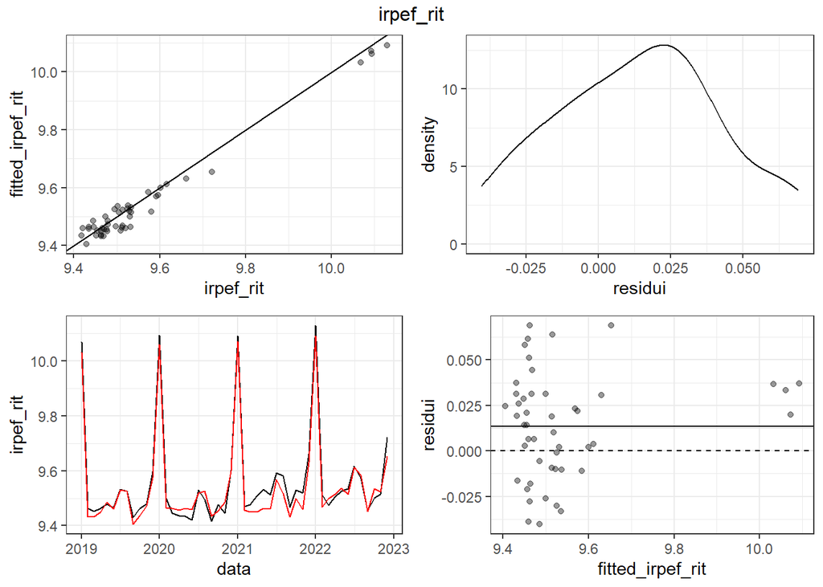

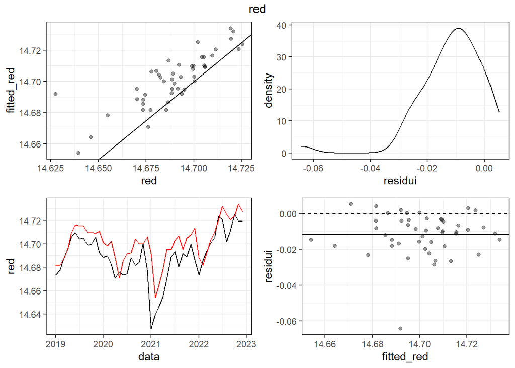

```r
# out of sample performance
predictions <- df %>%
              select(
                data, diva_int, fat, iva_imp,
                imp, accise, irpef_rit, red,
                starts_with('fitted'), starts_with('e_')) %>%
              filter(data >= '2019-01-01')


mean_residuals <- predictions %>%
                  select(starts_with('e')) %>%
                  na.omit() %>%
                  lapply(mean) %>%
                  as.numeric()

names(mean_residuals) <- variable_names


for (i in variable_names) {

  dati = predictions %>% select(data, contains(i))

  g1 = ggplot(dati, aes_string(x=i, y=paste0('fitted_',i))) +
          geom_point(alpha = .4) +
          geom_abline(slope=1, intercept=0) +
          theme_bw()

  g2 = ggplot(dati, aes_string(x = paste0('e_',i))) +
          geom_density() +
          xlab('residui') +
          theme_bw()

  g3 = ggplot(dati, aes_string(x='data', y = i)) +
    geom_line() +
    geom_line(aes_string(y=paste0('fitted_',i)), color='red') +
    theme_bw()

  g4 = ggplot(dati, aes_string(x=paste0('fitted_',i),  y=paste0('e_',i))) +
          geom_point(alpha=0.4) + ylab('residui') +
          geom_hline(yintercept = 0, lty=2) +
          geom_hline(yintercept = as.numeric(mean_residuals[i]), lty=1) + theme_bw()



  grid.arrange(g1, g2, g3, g4, nrow=2, top = i)


}
```

## Super Learner

```r
require(SuperLearner)

set.seed(371)

df_train = df %>% select(!starts_with('fitted')) %>%
    select(!starts_with('e')) %>%
    select(!starts_with('du')) %>%
    filter(data < '2019-01-01') %>% na.omit()

df_test = df %>% select(!starts_with('fitted')) %>%
    select(!starts_with('e')) %>%
    select(!starts_with('du')) %>%
    filter(data >= '2019-01-01') %>% na.omit()

X = df_train %>% select(starts_with('L'))

# tune = list(ntrees = c(100, 500, 1000),
#             max_depth = 1:4,
#             shrinkage = 0.01)

# Set detailed names = TRUE so we can see the configuration for each function.
# Also shorten the name prefix.
# learners = create.Learner("SL.xgboost", tune = tune, detailed_names = TRUE, name_prefix = "xgb")


# SL_library <- c("SL.mean", "SL.lm", "SL.glm", "SL.glmnet",  "SL.randomForest", "SL.ipredbagg")
#
# cv_sl = CV.SuperLearner(Y = df_train$diva_int, X = X,
#                            cvControl = list(V = 3),
#                            parallel = "multicore",
#                            SL.library = SL_library)
#
# summary(cv_sl)
#
# plot(cv_sl) + theme_bw()
#
# table(simplify2array(cv_sl$whichDiscreteSL))

SL_lib <- c('SL.mean', "SL.lm", "SL.nnet", "SL.glmnet", "SL.gam", "SL.randomForest", "SL.ipredbagg", "SL.xgboost")

modelli = SuperLearner(Y = df_train$diva_int,  X = X, SL.library = SL_lib)

coeff_SL = modelli$coef
coeff_SL
```

```
##         SL.mean_All           SL.lm_All         SL.nnet_All       SL.glmnet_All
##           0.0000000           0.1255802           0.2557989           0.3421779
##          SL.gam_All SL.randomForest_All    SL.ipredbagg_All      SL.xgboost_All
##           0.0000000           0.2764430           0.0000000           0.0000000
```

```r
yhat = predict(modelli, X)

# check
sum(as.matrix(yhat$library.predict) %*% coeff_SL == yhat$pred ) == length(yhat$pred)
```

```
## [1] TRUE
```

```r
yhat_diva_int = yhat$pred
y_values = df_train$diva_int
preds = data.frame(Prediction = yhat_diva_int, Actual = y_values)

# in-sample prediction
rsq(preds, estimate = Prediction, truth = Actual)
```

| .metric | .estimator | .estimate |
| --- | --- | --- |
| rsq | standard | 0.702618 |

```r
rmse(preds, estimate = Prediction, truth = Actual)
```

| .metric | .estimator | .estimate |
| --- | --- | --- |
| rmse | standard | 0.03419446 |

```r
# out-of-sample prediction
Xtest = df_test %>% select(starts_with('L'))
yf_diva_int = predict(modelli, Xtest)
yf_values = yf_diva_int$pred
y = df_test$diva_int
pred_test = data.frame(Prediction = yf_values, Actual = y)
rsq_diva_int = rsq(pred_test, estimate = Prediction, truth = Actual)
rmse_diva_int = rmse(pred_test, estimate = Prediction, truth = Actual)

all_prediction_diva_int = bind_rows(preds, pred_test)
rsq_diva_int_all = rsq(all_prediction_diva_int, estimate = Prediction, truth = Actual)
rmse_diva_int_all = rmse(all_prediction_diva_int, estimate = Prediction, truth = Actual)


dati = df %>% na.omit() %>% select(data, diva_int)  %>% bind_cols(all_prediction_diva_int) %>%
  mutate(Residuals = Prediction - Actual) %>% filter(data >= '2019-01-01')

# check
sum(dati$Actual == dati$diva_int) == nrow(dati)
```

```
## [1] TRUE
```

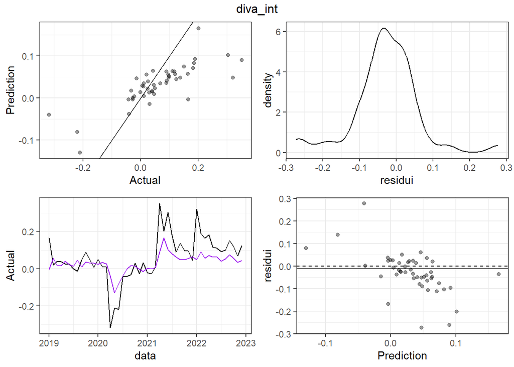

```r
g1 = ggplot(dati, aes_string(x='Actual', y='Prediction')) +
          geom_point(alpha = .4) +
          geom_abline(slope=1, intercept=0) +
          theme_bw()

g2 = ggplot(dati, aes_string(x = 'Residuals')) +
          geom_density() +
          xlab('residui') +
          theme_bw()

g3 = ggplot(dati, aes_string(x='data', y = 'Actual')) +
    geom_line() +
    geom_line(aes_string(y='Prediction'), color='purple') +
    theme_bw()

g4 = ggplot(dati, aes_string(x='Prediction',  y='Residuals')) +
          geom_point(alpha=0.4) + ylab('residui') +
          geom_hline(yintercept = 0, lty=2) +
          geom_hline(yintercept = as.numeric(mean_residuals[i]), lty=1) + theme_bw()



grid.arrange(g1, g2, g3, g4, nrow=2, top = 'diva_int')
```

Lets extend the same reasoning to all the four more relevant tax revenues $\{IVA_{INT}, \, \, IVA_{IMP} , \, \, ACCISE, \, \, IRPEF_{RIT}\}$. Keep in mind that the other three equations are auxiliary in the sense that they help to get an estimate of current endogenous variables. Here the approach is slightly different: we do not have, never, a current explanatory variables but we limit our-self to lagged (or lagged differenced) values only. Hence, we do not have an explicit need for the other three equations to be estimated; we just care about providing an alternative and valid estimation of the four major tax revenues - which is the same goal of MoME, by the way.

In the following the process is exactly the same as what we have already done for the $IVA_{INT}$ tax revenue variable, but applied to the other 3 variables.  
Firstly, we split the data into training (from 2002 to 2018) and test (all the remaining time periods) sets.  
Secondly, by using the training set only we train a set of competing parametric (LM), non-parametric (tree-based) or semi-parametric (Lasso/Ridge) models. Through V-fold cross validation we get the optimal hyper-parameters, than we re-train all of them on the full training dataset to assess individual performance and to get the optimal weights for the ensemble.  
Finally, we assess the ensemble performance both visually and quantitatively (by using $R^2$ and root mean squared error metrics).

```r
set.seed(371)


modelli = SuperLearner(Y = df_train$iva_imp,  X = X, SL.library = SL_lib)

coeff_SL = modelli$coef
coeff_SL
```

```
##         SL.mean_All           SL.lm_All         SL.nnet_All       SL.glmnet_All
##          0.00000000          0.47570354          0.00000000          0.01631509
##          SL.gam_All SL.randomForest_All    SL.ipredbagg_All      SL.xgboost_All
##          0.01349825          0.49448313          0.00000000          0.00000000
```

```r
yhat = predict(modelli, X)

# check
sum(as.matrix(yhat$library.predict) %*% coeff_SL == yhat$pred ) == length(yhat$pred)
```

```
## [1] TRUE
```

```r
yhat_iva_imp = yhat$pred
y_values = df_train$iva_imp
preds = data.frame(Prediction = yhat_iva_imp, Actual = y_values)

# in-sample prediction
rsq(preds, estimate = Prediction, truth = Actual)
```

| .metric | .estimator | .estimate |
| --- | --- | --- |
| rsq | standard | 0.8290617 |

```r
rmse(preds, estimate = Prediction, truth = Actual)
```

| .metric | .estimator | .estimate |
| --- | --- | --- |
| rmse | standard | 0.07178994 |

```r
# out-of-sample prediction
Xtest = df_test %>% select(starts_with('L'))
yf_iva_imp = predict(modelli, Xtest)
yf_values = yf_iva_imp$pred
y = df_test$iva_imp
pred_test = data.frame(Prediction = yf_values, Actual = y)
rsq_iva_imp = rsq(pred_test, estimate = Prediction, truth = Actual)
rmse_iva_imp = rmse(pred_test, estimate = Prediction, truth = Actual)

all_prediction_iva_imp = bind_rows(preds, pred_test)
rsq_iva_imp_all = rsq(all_prediction_iva_imp, estimate = Prediction, truth = Actual)
rmse_iva_imp_all = rmse(all_prediction_iva_imp, estimate = Prediction, truth = Actual)

dati = df %>% na.omit() %>% select(data, iva_imp)  %>% bind_cols(all_prediction_iva_imp) %>%
  mutate(Residuals = Prediction - Actual) %>% filter(data >= '2019-01-01')

# check
sum(dati$Actual == dati$iva_imp) == nrow(dati)
```

```
## [1] TRUE
```

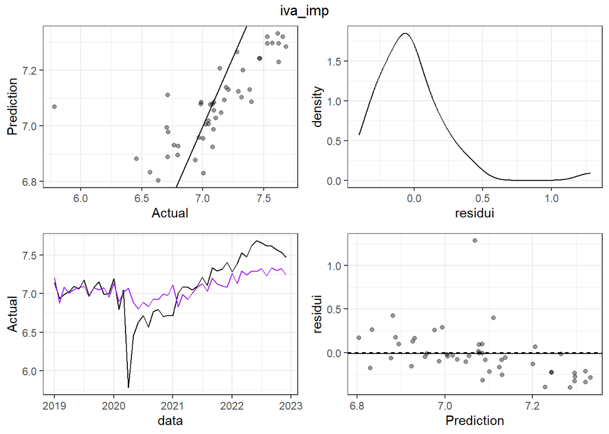

```r
g1 = ggplot(dati, aes_string(x='Actual', y='Prediction')) +
          geom_point(alpha = .4) +
          geom_abline(slope=1, intercept=0) +
          theme_bw()

g2 = ggplot(dati, aes_string(x = 'Residuals')) +
          geom_density() +
          xlab('residui') +
          theme_bw()

g3 = ggplot(dati, aes_string(x='data', y = 'Actual')) +
    geom_line() +
    geom_line(aes_string(y='Prediction'), color='purple') +
    theme_bw()

g4 = ggplot(dati, aes_string(x='Prediction',  y='Residuals')) +
          geom_point(alpha=0.4) + ylab('residui') +
          geom_hline(yintercept = 0, lty=2) +
          geom_hline(yintercept = as.numeric(mean_residuals[i]), lty=1) + theme_bw()

grid.arrange(g1, g2, g3, g4, nrow=2, top = 'iva_imp')
```

```r
set.seed(371)


modelli = SuperLearner(Y = df_train$accise,  X = X, SL.library = SL_lib)

coeff_SL = modelli$coef
coeff_SL
```

```
##         SL.mean_All           SL.lm_All         SL.nnet_All       SL.glmnet_All
##           0.0000000           0.0000000           0.0000000           0.4019929
##          SL.gam_All SL.randomForest_All    SL.ipredbagg_All      SL.xgboost_All
##           0.0000000           0.2595391           0.0000000           0.3384680
```

```r
yhat = predict(modelli, X)

# check
sum(as.matrix(yhat$library.predict) %*% coeff_SL == yhat$pred ) == length(yhat$pred)
```

```
## [1] TRUE
```

```r
yhat_accise = yhat$pred
y_values = df_train$accise
preds = data.frame(Prediction = yhat_accise, Actual = y_values)

# in-sample prediction
rsq(preds, estimate = Prediction, truth = Actual)
```

| .metric | .estimator | .estimate |
| --- | --- | --- |
| rsq | standard | 0.968407 |

```r
rmse(preds, estimate = Prediction, truth = Actual)
```

| .metric | .estimator | .estimate |
| --- | --- | --- |
| rmse | standard | 0.04397466 |

```r
# out-of-sample prediction
Xtest = df_test %>% select(starts_with('L'))
yf_accise = predict(modelli, Xtest)
yf_values = yf_accise$pred
y = df_test$accise
pred_test = data.frame(Prediction = yf_values, Actual = y)
rsq_accise = rsq(pred_test, estimate = Prediction, truth = Actual)
rmse_accise = rmse(pred_test, estimate = Prediction, truth = Actual)

all_prediction_accise = bind_rows(preds, pred_test)
rsq_accise_all = rsq(all_prediction_accise, estimate = Prediction, truth = Actual)
rmse_accise_all = rmse(all_prediction_accise, estimate = Prediction, truth = Actual)

dati = df %>% na.omit() %>% select(data, accise)  %>% bind_cols(all_prediction_accise) %>%
  mutate(Residuals = Prediction - Actual) %>% filter(data >= '2019-01-01')

# check
sum(dati$Actual == dati$accise) == nrow(dati)
```

```
## [1] TRUE
```

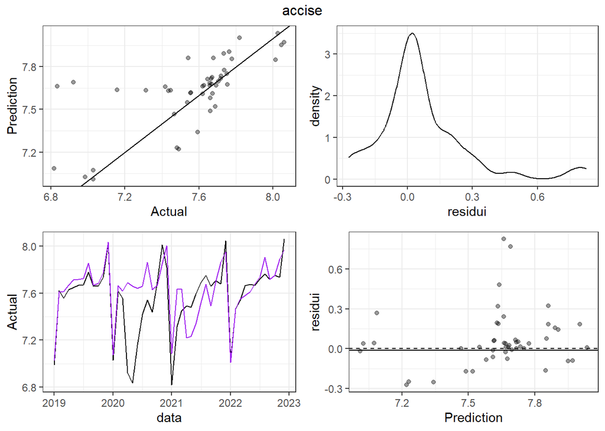

```r
g1 = ggplot(dati, aes_string(x='Actual', y='Prediction')) +
          geom_point(alpha = .4) +
          geom_abline(slope=1, intercept=0) +
          theme_bw()

g2 = ggplot(dati, aes_string(x = 'Residuals')) +
          geom_density() +
          xlab('residui') +
          theme_bw()

g3 = ggplot(dati, aes_string(x='data', y = 'Actual')) +
    geom_line() +
    geom_line(aes_string(y='Prediction'), color='purple') +
    theme_bw()

g4 = ggplot(dati, aes_string(x='Prediction',  y='Residuals')) +
          geom_point(alpha=0.4) + ylab('residui') +
          geom_hline(yintercept = 0, lty=2) +
          geom_hline(yintercept = as.numeric(mean_residuals[i]), lty=1) + theme_bw()

grid.arrange(g1, g2, g3, g4, nrow=2, top = 'accise')
```

```r
set.seed(371)


modelli = SuperLearner(Y = df_train$irpef_rit,  X = X, SL.library = SL_lib)

coeff_SL = modelli$coef
coeff_SL
```

```
##         SL.mean_All           SL.lm_All         SL.nnet_All       SL.glmnet_All
##           0.0000000           0.4781848           0.0000000           0.2960780
##          SL.gam_All SL.randomForest_All    SL.ipredbagg_All      SL.xgboost_All
##           0.0000000           0.1106322           0.0000000           0.1151050
```

```r
yhat = predict(modelli, X)

# check
sum(as.matrix(yhat$library.predict) %*% coeff_SL == yhat$pred ) == length(yhat$pred)
```

```
## [1] TRUE
```

```r
yhat_irpef_rit = yhat$pred
y_values = df_train$irpef_rit
preds = data.frame(Prediction = yhat_irpef_rit, Actual = y_values)
rsq(preds, estimate = Prediction, truth = Actual)
```

| .metric | .estimator | .estimate |
| --- | --- | --- |
| rsq | standard | 0.9730455 |

```r
rmse(preds, estimate = Prediction, truth = Actual)
```

| .metric | .estimator | .estimate |
| --- | --- | --- |
| rmse | standard | 0.03701961 |

```r
# out-of-sample prediction
Xtest = df_test %>% select(starts_with('L'))
yf_irpef_rit = predict(modelli, Xtest)
yf_values = yf_irpef_rit$pred
y = df_test$irpef_rit
pred_test = data.frame(Prediction = yf_values, Actual = y)
rsq_irpef_rit = rsq(pred_test, estimate = Prediction, truth = Actual)
rmse_irpef_rit = rmse(pred_test, estimate = Prediction, truth = Actual)

all_prediction_irpef_rit = bind_rows(preds, pred_test)
rsq_irpef_rit_all = rsq(all_prediction_irpef_rit, estimate = Prediction, truth = Actual)
rmse_irpef_rit_all = rmse(all_prediction_irpef_rit, estimate = Prediction, truth = Actual)

dati = df %>% na.omit() %>% select(data, irpef_rit)  %>% bind_cols(all_prediction_irpef_rit) %>%
  mutate(Residuals = Prediction - Actual) %>% filter(data >= '2019-01-01')

# check
sum(dati$Actual == dati$irpef_rit) == nrow(dati)
```

```
## [1] TRUE
```

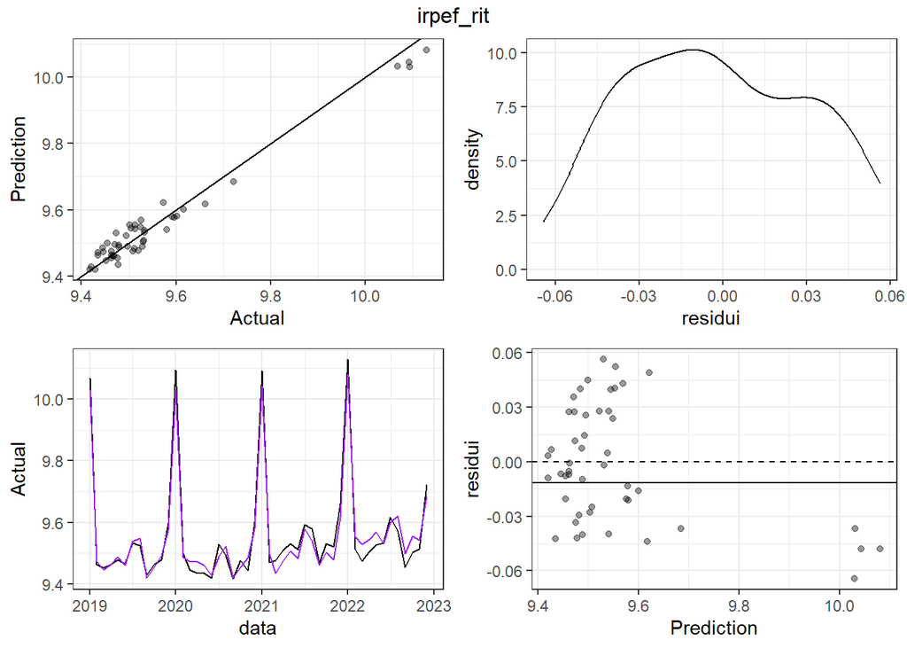

```r
g1 = ggplot(dati, aes_string(x='Actual', y='Prediction')) +
          geom_point(alpha = .4) +
          geom_abline(slope=1, intercept=0) +
          theme_bw()

g2 = ggplot(dati, aes_string(x = 'Residuals')) +
          geom_density() +
          xlab('residui') +
          theme_bw()

g3 = ggplot(dati, aes_string(x='data', y = 'Actual')) +
    geom_line() +
    geom_line(aes_string(y='Prediction'), color='purple') +
    theme_bw()

g4 = ggplot(dati, aes_string(x='Prediction',  y='Residuals')) +
          geom_point(alpha=0.4) + ylab('residui') +
          geom_hline(yintercept = 0, lty=2) +
          geom_hline(yintercept = as.numeric(mean_residuals[i]), lty=1) + theme_bw()

grid.arrange(g1, g2, g3, g4, nrow=2, top = 'irpef_rit')
```

## MoME and SuperLearner results side by side

In this section we will review, side by side, both MoME and SuperLearner predictions in the full dataset (from january 2002 to January 2023) and in the test set only (from January 2019 to January 2023).

```r
# aggregate performance SL

performance_SL_outofsample = bind_rows(rmse_diva_int, rsq_diva_int, rmse_iva_imp, rsq_iva_imp,
                           rmse_accise, rsq_accise, rmse_irpef_rit, rsq_irpef_rit)

performance_SL_outofsample$.estimator = c(rep('diva_int',2), rep('iva_imp',2),
                              rep('accise',2), rep('irpef_rit',2))

performance_SL_outofsample = performance_SL_outofsample %>% rename(.variable = .estimator) %>%
  mutate(.model = 'SuperLearner')


performance_SL = bind_rows(rmse_diva_int_all, rsq_diva_int_all, rmse_iva_imp_all, rsq_iva_imp_all,
                           rmse_accise_all, rsq_accise_all, rmse_irpef_rit_all, rsq_irpef_rit_all)

performance_SL$.estimator = c(rep('diva_int',2), rep('iva_imp',2),
                              rep('accise',2), rep('irpef_rit',2))


performance_SL = performance_SL %>% rename(.variable = .estimator) %>%
  mutate(.model = 'SuperLearner')

# metrics overall
bind_rows(performance_MOME, performance_SL)
```

| .metric | .variable | .estimate | .model |
| --- | --- | --- | --- |
| rmse | diva_int | 0.05205560 | MoME |
| rsq | diva_int | 0.51268658 | MoME |
| rmse | iva_imp | 0.15134276 | MoME |
| rsq | iva_imp | 0.54975804 | MoME |
| rmse | accise | 0.19285433 | MoME |
| rsq | accise | 0.46928358 | MoME |
| rmse | irpef_rit | 0.04749049 | MoME |
| rsq | irpef_rit | 0.96416898 | MoME |
| rmse | diva_int | 0.05443580 | SuperLearner |
| rsq | diva_int | 0.66306083 | SuperLearner |

[output cut: 6 more lines]

```r
# metrics on test set only
bind_rows(performance_MoME_outofsample, performance_SL_outofsample)
```

| .metric | .variable | .estimate | .model |
| --- | --- | --- | --- |
| rmse | diva_int | 0.07214167 | MoME |
| rsq | diva_int | 0.65668152 | MoME |
| rmse | iva_imp | 0.22880473 | MoME |
| rsq | iva_imp | 0.61216418 | MoME |
| rmse | accise | 0.24831312 | MoME |
| rsq | accise | 0.35912797 | MoME |
| rmse | irpef_rit | 0.03158839 | MoME |
| rsq | irpef_rit | 0.97392368 | MoME |
| rmse | diva_int | 0.09377495 | SuperLearner |
| rsq | diva_int | 0.63285899 | SuperLearner |

[output cut: 6 more lines]